# Metropolis-Hastings Algorithm Demo

Ethan Smith

## Introduction

The **Metropolis_Hastings algorithm** is a Markov Chain Monte Carlo method for generating samples from a target distribution when direct sampling is difficult. It constructs a Markov chain that has the target distribution as its stationary distribution.

For this project, we implement a 2-dimensional version of the algorithm, targeting a bivariate distribution.

$$f(a, b) \propto \exp(-2a^2 - 2ab - b^2)$$

Since this isn’t a standard distribution we use Markov Chain Monte Carlo to approximate samples from it.

## How the Metropolis-Hastings Algorithm Works

The algorithm operates as follows:

1. **Initialization**: Start at a point in the domain.
2. **Proposal Step**: Generate a candidate point from a proposal distribution.
3. **Acceptance Step**: Compute the acceptance ratio:

$$\alpha = \min\left(1, \frac{f(\text{candidate}) \cdot
q(\text{current}|\text{candidate})}{f(\text{current}) \cdot
q(\text{candidate}|\text{current})}\right)$$

Where: - $f$ is the unnormalized target density - $q$ is the proposal density

4. **Decision Step**: Accept the candidate with probability $\alpha$. Otherwise, stay at the current point.
5. **Repeat**: Run many iterations to approximate the target distribution.

## R Implementation

We now process the samples and compute key statistics.

This shows the proportion of accepted proposals, which helps assess how well the algorithm is exploring the space. Acceptance rates between 20–50% are often ideal.

These give us empirical probabilities for events under the target distribution, estimated using our Markov chain samples.

```r
# Convert to dataframe
mh_df <- bind_rows(samples)

# Save to CSV
write.csv(mh_df, "mh_simulated_output.csv", row.names = FALSE)

# Read back in (to fulfill stretch challenge)
mh_df <- read.csv("mh_simulated_output.csv")


# Remove burn-in
post_burn <- mh_df %>% filter(iteration > burn_in)

# Acceptance rate
post_burn %>%
  count(accepted) %>%
  mutate(rate = n / sum(n))
```

```
##   accepted     n      rate
## 1    FALSE 36943 0.7539388
## 2     TRUE 12057 0.2460612
```

```r
# Estimate P(x < -1)
mean(post_burn$x < -1)
```

```
## [1] 0.07934694
```

```r
# Estimate P(y > 2)
mean(post_burn$y > 2)
```

```
## [1] 0.02173469
```

```r
# Estimate P(x * y < 0)
mean(post_burn$x * post_burn$y < 0)
```

```
## [1] 0.7545714
```

Finally we create a 2D density plot showing the density of x and y after burn in.This plot shows where the samples are most concentrated, which helps visualize the shape of the distribution we were targeting.

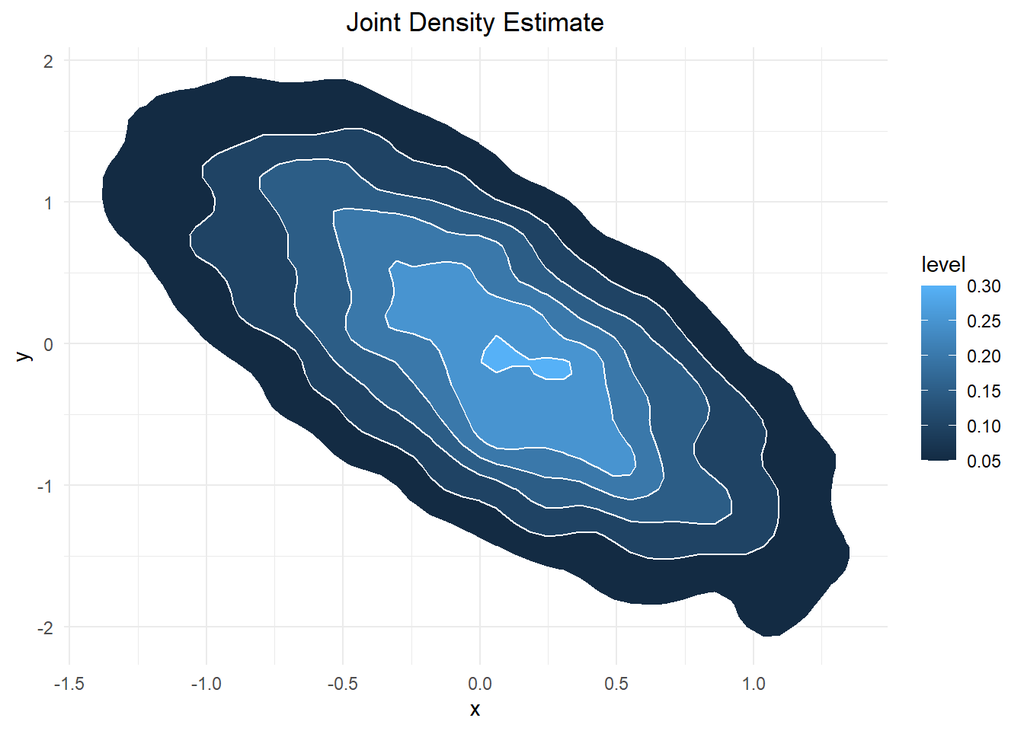

```r
# 2D Density Plot
ggplot(post_burn, aes(x = x, y = y)) +
  stat_density_2d(aes(fill = ..level..), geom = "polygon", color = "white") +
  labs(title = "Joint Density Estimate", x = "x", y = "y") +
  theme_minimal() +
  theme(plot.title = element_text(hjust = 0.5))
```

## Conclusion

In this notebook, we successfully implemented the Metropolis-Hastings algorithm to simulate samples from a complex bivariate distribution. The project demonstrates:

Core logic of MCMC

Uses at least 5 data types (numeric, character, logical, data frame, function)

Displays output to screen

Writes/reads from a CSV file (stretch challenge)

Meaningful statistical summaries

Visualization of the resulting distribution

This technique is broadly useful in Bayesian statistics and any scenario where direct sampling is difficult.